# Notebook

OK let's proceed to use the train method of the caret package to train a logistic regression model. We'll use one of the most common crossvalidation methods namely the 3x 10-fold CV. That is 10 folds of data to split train and cv repeated 3 times.

```python
%%R
#Define the 3x 10 fold cv control using the traincontrol method of caret.
tenfoldcv<-trainControl(method='repeatedcv', number=10, repeats=3)
```

```python
%%R
#Train a logistic regression classifier using the train method of the caret package. Everything is same as before except
#we use the train function and pass glm as the method.

#Install the doSNOW package to leverage multiple cores - parallelization
#install.packages(doSNOW)
library(doSNOW)

#Set 4 below to the number of cores you'd like to run in parallel. I have 4 and using 3 of them!
cl <- makeCluster(3, type="SOCK")
registerDoSNOW(cl)

#Note that I've also added options below to normalize the features (Feature Scaling)
set.seed(35)
logit.tune1<-train(Survived ~ Sex + Pclass + Age + SibSp + Embarked + FareGroup + FamID + Title,
                data=train.set,
                method='glm',
                preProcess = c("center", "scale"),
                trControl=tenfoldcv)

logit.tune1

#May need to install a dependency for caret train
#install.packages('e1071', dependencies=TRUE)
```

```
Generalized Linear Model

714 samples
 14 predictors
  2 classes: '0', '1'

Pre-processing: centered, scaled
Resampling: Cross-Validated (10 fold, repeated 3 times)

Summary of sample sizes: 643, 643, 643, 642, 643, 643, ...

Resampling results

  Accuracy   Kappa      Accuracy SD  Kappa SD
  0.7829812  0.5332698  0.05484398   0.1230111
```

```python
%%R
summary(logit.tune1)
```

```
Call:
NULL

Deviance Residuals:
     Min        1Q    Median        3Q       Max
-2.28940  -0.43374  -0.00008   0.00010   2.42885

Coefficients: (45 not defined because of singularities)
                              Estimate Std. Error z value Pr(>|z|)
(Intercept)                 -6.178e-01  2.122e+02  -0.003   0.9977
Sexmale                     -1.065e+01  3.540e+03  -0.003   0.9976
Pclass2                     -4.784e-01  2.887e-01  -1.657   0.0975 .
Pclass3                     -5.451e-01  3.414e-01  -1.597   0.1103
Age                         -3.162e-01  1.743e-01  -1.814   0.0697 .
SibSp                        2.275e-01  6.706e-01   0.339   0.7344
EmbarkedQ                    8.080e-02  1.658e-01   0.487   0.6259
EmbarkedS                   -1.214e-01  1.804e-01  -0.673   0.5010
`FareGroup10-20`             2.253e-01  2.610e-01   0.863   0.3880
`FareGroup20-40`             5.179e-01  2.891e-01   1.792   0.0732 .
`FareGroup40+`               4.250e-01  2.883e-01   1.474   0.1404
FamIDAbelson2               -6.050e-03  1.922e-01  -0.031   0.9749
FamIDAhlin2                         NA         NA      NA       NA
FamIDAks2                    6.886e-01  4.025e+02   0.002   0.9986
FamIDAllison4               -1.184e+00  3.883e+02  -0.003   0.9976
`FamIDAndersen-Jensen2`      7.532e-01  4.025e+02   0.002   0.9985
FamIDAndersson7             -1.938e-01  2.168e-01  -0.894   0.3714
FamIDAndrews2                7.125e-01  4.025e+02   0.002   0.9986
FamIDAngle2                         NA         NA      NA       NA
FamIDAppleton3               6.236e-01  4.025e+02   0.002   0.9988
`FamIDArnold-Franchi2`      -1.073e+00  3.092e+02  -0.003   0.9972
FamIDAsplund7               -6.470e-02  1.963e-01  -0.330   0.7417
FamIDAstor2                         NA         NA      NA       NA
FamIDBackstrom2             -6.092e-01  4.025e+02  -0.002   0.9988
FamIDBackstrom4              6.570e-01  4.025e+02   0.002   0.9987
FamIDBaclini4                9.648e-01  3.949e+02   0.002   0.9981
FamIDBarbara2               -1.079e+00  3.893e+02  -0.003   0.9978
FamIDBaxter2                -3.612e-02  1.847e-01  -0.195   0.8450
FamIDBeane2                  8.323e-01  4.025e+02   0.002   0.9983
FamIDBecker4                 6.907e-01  4.025e+02   0.002   0.9986
FamIDBeckwith3               1.070e+00  3.166e+02   0.003   0.9973
```

[output cut: 206 more lines]

```
FamIDZabour2                -7.397e-01  4.025e+02  -0.002   0.9985
TitleMiss                   -8.997e+00  3.011e+03  -0.003   0.9976
TitleMr                     -1.393e+00  7.860e-01  -1.772   0.0764 .
TitleMrs                    -7.105e+00  2.603e+03  -0.003   0.9978
TitleNoble                  -5.542e-01  2.803e-01  -1.977   0.0480 *
---
Signif. codes:  0 ‘***’ 0.001 ‘**’ 0.01 ‘*’ 0.05 ‘.’ 0.1 ‘ ’ 1

(Dispersion parameter for binomial family taken to be 1)

    Null deviance: 950.86  on 713  degrees of freedom
Residual deviance: 373.30  on 517  degrees of freedom
AIC: 767.3

Number of Fisher Scoring iterations: 18
```

Okay looks like we're doing (un)reasonably well. Let's try a couple of interesting ideas. **Class Compression** refers to collapsing some levels on a categorical variable. In layman terms, making a factor two-level. So for instance, we have Embarked, most of which has the value 'S' as we saw earlier. We can use the I() function when training to shrink this to S or otherwise. Let's do that.

```python
%%R
#Let's set class compression on Embarked to 'S' or otherwise.
set.seed(35)

logit.tune2<-train(Survived ~ Sex + Pclass + Age + SibSp + I(Embarked=='S') + FareGroup + FamID + Title,
                data=train.set,
                method='glm',
                preProcess = c("center", "scale"),
                trControl=tenfoldcv)

logit.tune2
```

```
Generalized Linear Model

714 samples
 14 predictors
  2 classes: '0', '1'

Pre-processing: centered, scaled
Resampling: Cross-Validated (10 fold, repeated 3 times)

Summary of sample sizes: 643, 643, 643, 642, 643, 643, ...

Resampling results

  Accuracy   Kappa    Accuracy SD  Kappa SD
  0.7820488  0.53063  0.05507752   0.1240941
```

```python
%%R
summary(logit.tune2)
```

```
Call:
NULL

Deviance Residuals:
     Min        1Q    Median        3Q       Max
-2.34231  -0.43582  -0.00008   0.00010   2.42395

Coefficients: (45 not defined because of singularities)
                              Estimate Std. Error z value Pr(>|z|)
(Intercept)                 -6.156e-01  2.122e+02  -0.003   0.9977
Sexmale                     -1.065e+01  3.548e+03  -0.003   0.9976
Pclass2                     -4.596e-01  2.869e-01  -1.602   0.1092
Pclass3                     -5.264e-01  3.407e-01  -1.545   0.1223
Age                         -3.148e-01  1.749e-01  -1.800   0.0718 .
SibSp                        2.230e-01  6.716e-01   0.332   0.7398
`I(Embarked == "S")TRUE`    -1.728e-01  1.444e-01  -1.197   0.2315
`FareGroup10-20`             2.101e-01  2.593e-01   0.810   0.4177
`FareGroup20-40`             5.142e-01  2.900e-01   1.773   0.0762 .
`FareGroup40+`               4.068e-01  2.876e-01   1.415   0.1572
FamIDAbelson2               -1.258e-02  1.918e-01  -0.066   0.9477
FamIDAhlin2                         NA         NA      NA       NA
FamIDAks2                    6.882e-01  4.025e+02   0.002   0.9986
FamIDAllison4               -1.181e+00  3.885e+02  -0.003   0.9976
`FamIDAndersen-Jensen2`      7.511e-01  4.025e+02   0.002   0.9985
FamIDAndersson7             -1.949e-01  2.170e-01  -0.898   0.3690
FamIDAndrews2                7.132e-01  4.025e+02   0.002   0.9986
FamIDAngle2                         NA         NA      NA       NA
FamIDAppleton3               6.264e-01  4.025e+02   0.002   0.9988
`FamIDArnold-Franchi2`      -1.072e+00  3.092e+02  -0.003   0.9972
FamIDAsplund7               -6.467e-02  1.965e-01  -0.329   0.7421
FamIDAstor2                         NA         NA      NA       NA
FamIDBackstrom2             -6.081e-01  4.025e+02  -0.002   0.9988
FamIDBackstrom4              6.584e-01  4.025e+02   0.002   0.9987
FamIDBaclini4                9.586e-01  3.950e+02   0.002   0.9981
FamIDBarbara2               -1.085e+00  3.895e+02  -0.003   0.9978
FamIDBaxter2                -3.857e-02  1.849e-01  -0.209   0.8347
FamIDBeane2                  8.320e-01  4.025e+02   0.002   0.9984
FamIDBecker4                 6.901e-01  4.025e+02   0.002   0.9986
FamIDBeckwith3               1.073e+00  3.164e+02   0.003   0.9973
FamIDBishop2                 5.893e-01  4.025e+02   0.001   0.9988
```

[output cut: 205 more lines]

```
FamIDZabour2                -7.448e-01  4.025e+02  -0.002   0.9985
TitleMiss                   -8.980e+00  3.017e+03  -0.003   0.9976
TitleMr                     -1.399e+00  7.872e-01  -1.778   0.0755 .
TitleMrs                    -7.107e+00  2.608e+03  -0.003   0.9978
TitleNoble                  -5.585e-01  2.807e-01  -1.989   0.0467 *
---
Signif. codes:  0 ‘***’ 0.001 ‘**’ 0.01 ‘*’ 0.05 ‘.’ 0.1 ‘ ’ 1

(Dispersion parameter for binomial family taken to be 1)

    Null deviance: 950.86  on 713  degrees of freedom
Residual deviance: 373.54  on 518  degrees of freedom
AIC: 765.54

Number of Fisher Scoring iterations: 18
```

```python
%%R
#Let's work in an interaction between Pclass and Sex.
set.seed(35)

logit.tune3<-train(Survived ~ Sex + Pclass + Sex:Pclass + Age + SibSp + Embarked + FareGroup + FamID + Title,
                data=train.set,
                method='glm',
                preProcess = c("center", "scale"),
                trControl=tenfoldcv)

logit.tune3
```

```
Generalized Linear Model

714 samples
 14 predictors
  2 classes: '0', '1'

Pre-processing: centered, scaled
Resampling: Cross-Validated (10 fold, repeated 3 times)

Summary of sample sizes: 643, 643, 643, 642, 643, 643, ...

Resampling results

  Accuracy   Kappa      Accuracy SD  Kappa SD
  0.7904864  0.5472096  0.05401862   0.1249195
```

```python
%%R
summary(logit.tune3)
```

```
Call:
NULL

Deviance Residuals:
     Min        1Q    Median        3Q       Max
-2.85112  -0.46296  -0.00009   0.00009   2.54282

Coefficients: (45 not defined because of singularities)
                              Estimate Std. Error z value Pr(>|z|)
(Intercept)                 -5.350e-01  2.135e+02  -0.003   0.9980
Sexmale                     -1.099e+01  3.407e+03  -0.003   0.9974
Pclass2                     -7.112e-01  6.345e-01  -1.121   0.2623
Pclass3                     -1.487e+00  7.122e-01  -2.088   0.0368 *
Age                         -3.107e-01  1.799e-01  -1.727   0.0842 .
SibSp                        2.551e-02  6.888e-01   0.037   0.9705
EmbarkedQ                    1.342e-01  1.615e-01   0.831   0.4058
EmbarkedS                   -1.049e-01  1.818e-01  -0.577   0.5640
`FareGroup10-20`             1.840e-01  2.615e-01   0.704   0.4816
`FareGroup20-40`             5.310e-01  2.953e-01   1.798   0.0721 .
`FareGroup40+`               3.425e-01  3.013e-01   1.137   0.2556
FamIDAbelson2               -2.723e-02  1.935e-01  -0.141   0.8881
FamIDAhlin2                         NA         NA      NA       NA
FamIDAks2                    7.047e-01  4.025e+02   0.002   0.9986
FamIDAllison4               -1.250e+00  3.928e+02  -0.003   0.9975
`FamIDAndersen-Jensen2`      7.543e-01  4.025e+02   0.002   0.9985
FamIDAndersson7             -1.563e-01  1.910e-01  -0.818   0.4132
FamIDAndrews2                6.498e-01  4.025e+02   0.002   0.9987
FamIDAngle2                         NA         NA      NA       NA
FamIDAppleton3               5.904e-01  4.025e+02   0.001   0.9988
`FamIDArnold-Franchi2`      -1.044e+00  3.351e+02  -0.003   0.9975
FamIDAsplund7               -3.992e-02  1.723e-01  -0.232   0.8168
FamIDAstor2                         NA         NA      NA       NA
FamIDBackstrom2             -6.261e-01  4.025e+02  -0.002   0.9988
FamIDBackstrom4              6.981e-01  4.025e+02   0.002   0.9986
FamIDBaclini4                9.878e-01  3.963e+02   0.002   0.9980
FamIDBarbara2               -1.059e+00  3.933e+02  -0.003   0.9979
FamIDBaxter2                -7.557e-02  1.924e-01  -0.393   0.6945
FamIDBeane2                  8.272e-01  4.025e+02   0.002   0.9984
FamIDBecker4                 7.046e-01  4.025e+02   0.002   0.9986
FamIDBeckwith3               1.064e+00  3.177e+02   0.003   0.9973
```

[output cut: 208 more lines]

```
TitleMr                     -1.242e+00  7.618e-01  -1.630   0.1030
TitleMrs                    -6.906e+00  2.505e+03  -0.003   0.9978
TitleNoble                  -5.001e-01  2.775e-01  -1.802   0.0716 .
`Sexmale:Pclass2`            1.211e-01  4.900e-01   0.247   0.8048
`Sexmale:Pclass3`            1.035e+00  6.352e-01   1.630   0.1031
---
Signif. codes:  0 ‘***’ 0.001 ‘**’ 0.01 ‘*’ 0.05 ‘.’ 0.1 ‘ ’ 1

(Dispersion parameter for binomial family taken to be 1)

    Null deviance: 950.86  on 713  degrees of freedom
Residual deviance: 366.58  on 515  degrees of freedom
AIC: 764.58

Number of Fisher Scoring iterations: 18
```

So we did a little bit better. I would just like to test a theory. We manufactured the FamilyID and have been doing well so far. What happens if we take it out? Will we do worse or better? Let's check it out.

```python
%%R
#Let's work in an interaction between Pclass and Sex.
set.seed(35)

logit.tune4<-train(Survived ~ Sex + Pclass + Sex:Pclass + Age + SibSp + Embarked + FareGroup + Title,
                data=train.set,
                method='glm',
                preProcess = c("center", "scale"),
                trControl=tenfoldcv)

logit.tune4
```

```
Generalized Linear Model

714 samples
 14 predictors
  2 classes: '0', '1'

Pre-processing: centered, scaled
Resampling: Cross-Validated (10 fold, repeated 3 times)

Summary of sample sizes: 643, 643, 643, 642, 643, 643, ...

Resampling results

  Accuracy   Kappa      Accuracy SD  Kappa SD
  0.8123305  0.5934912  0.04130739   0.09243173
```

```python
%%R
summary(logit.tune4)
```

```
Call:
NULL

Deviance Residuals:
    Min       1Q   Median       3Q      Max
-2.6591  -0.5397  -0.4099   0.3937   2.4194

Coefficients:
                   Estimate Std. Error z value Pr(>|z|)
(Intercept)        -0.56336    0.12309  -4.577 4.72e-06 ***
Sexmale            -8.13159  278.33333  -0.029 0.976693
Pclass2            -0.36485    0.33842  -1.078 0.280987
Pclass3            -1.62269    0.37865  -4.285 1.82e-05 ***
Age                -0.30128    0.13506  -2.231 0.025693 *
SibSp              -0.62972    0.17467  -3.605 0.000312 ***
EmbarkedQ           0.04973    0.11805   0.421 0.673568
EmbarkedS          -0.17619    0.12541  -1.405 0.160047
`FareGroup10-20`    0.07364    0.14908   0.494 0.621326
`FareGroup20-40`   -0.01342    0.17629  -0.076 0.939314
`FareGroup40+`      0.11277    0.22144   0.509 0.610572
TitleMiss          -6.75940  236.67998  -0.029 0.977216
TitleMr            -1.55762    0.29962  -5.199 2.01e-07 ***
TitleMrs           -5.78595  204.63657  -0.028 0.977443
TitleNoble         -0.46573    0.14315  -3.253 0.001140 **
`Sexmale:Pclass2`  -0.32045    0.29394  -1.090 0.275630
`Sexmale:Pclass3`   0.65008    0.35598   1.826 0.067823 .
---
Signif. codes:  0 ‘***’ 0.001 ‘**’ 0.01 ‘*’ 0.05 ‘.’ 0.1 ‘ ’ 1

(Dispersion parameter for binomial family taken to be 1)

    Null deviance: 950.86  on 713  degrees of freedom
Residual deviance: 576.85  on 697  degrees of freedom
AIC: 610.85

Number of Fisher Scoring iterations: 13
```

So we actually did **much** better. So lesson learnt, engineering new features is a great idea but may or may not positively impact your model. In fact, if we don't get it right, it could have an adverse impact. Let's see if we can make anymore tiny improvements with the Title. We have 4 possible values and I am going to class compress each.

```python
%%R
#Let's work in an interaction between Pclass and Sex.
set.seed(35)

logit.tune5<-train(Survived ~ Sex + Pclass + Sex:Pclass + Age + SibSp + Embarked + FareGroup + I(Title=='Mr') +
                   I(Title=='Mrs') + I(Title=='Miss') + I(Title=='Noble'),
                data=train.set,
                method='glm',
                preProcess = c("center", "scale"),
                trControl=tenfoldcv)

logit.tune5
```

```
Generalized Linear Model

714 samples
 14 predictors
  2 classes: '0', '1'

Pre-processing: centered, scaled
Resampling: Cross-Validated (10 fold, repeated 3 times)

Summary of sample sizes: 643, 643, 643, 642, 643, 643, ...

Resampling results

  Accuracy   Kappa      Accuracy SD  Kappa SD
  0.8123305  0.5934912  0.04130739   0.09243173
```

```python
%%R
summary(logit.tune5)
```

```
Call:
NULL

Deviance Residuals:
    Min       1Q   Median       3Q      Max
-2.6591  -0.5397  -0.4099   0.3937   2.4194

Coefficients:
                           Estimate Std. Error z value Pr(>|z|)
(Intercept)                -0.56336    0.12309  -4.577 4.72e-06 ***
Sexmale                    -8.13159  278.33333  -0.029 0.976693
Pclass2                    -0.36485    0.33842  -1.078 0.280987
Pclass3                    -1.62269    0.37865  -4.285 1.82e-05 ***
Age                        -0.30128    0.13506  -2.231 0.025693 *
SibSp                      -0.62972    0.17467  -3.605 0.000312 ***
EmbarkedQ                   0.04973    0.11805   0.421 0.673568
EmbarkedS                  -0.17619    0.12541  -1.405 0.160047
`FareGroup10-20`            0.07364    0.14908   0.494 0.621326
`FareGroup20-40`           -0.01342    0.17629  -0.076 0.939314
`FareGroup40+`              0.11277    0.22144   0.509 0.610572
`I(Title == "Mr")TRUE`     -1.55762    0.29962  -5.199 2.01e-07 ***
`I(Title == "Mrs")TRUE`    -5.78595  204.63657  -0.028 0.977443
`I(Title == "Miss")TRUE`   -6.75940  236.67998  -0.029 0.977216
`I(Title == "Noble")TRUE`  -0.46573    0.14315  -3.253 0.001140 **
`Sexmale:Pclass2`          -0.32045    0.29394  -1.090 0.275630
`Sexmale:Pclass3`           0.65008    0.35598   1.826 0.067823 .
---
Signif. codes:  0 ‘***’ 0.001 ‘**’ 0.01 ‘*’ 0.05 ‘.’ 0.1 ‘ ’ 1

(Dispersion parameter for binomial family taken to be 1)

    Null deviance: 950.86  on 713  degrees of freedom
Residual deviance: 576.85  on 697  degrees of freedom
AIC: 610.85

Number of Fisher Scoring iterations: 13
```

Hmm, didn't really make a difference. Let's try one last thing, adding Child, which we derived during the feature engineering exercise.

```python
%%R
#Let's add Child to the mix.
set.seed(35)

logit.tune6<-train(Survived ~ Sex + Pclass + Sex:Pclass + Age + SibSp + Embarked + FareGroup + Title + Child,
                data=train.set,
                method='glm',
                preProcess = c("center", "scale"),
                trControl=tenfoldcv)

logit.tune6
```

```
Generalized Linear Model

714 samples
 14 predictors
  2 classes: '0', '1'

Pre-processing: centered, scaled
Resampling: Cross-Validated (10 fold, repeated 3 times)

Summary of sample sizes: 643, 643, 643, 642, 643, 643, ...

Resampling results

  Accuracy   Kappa      Accuracy SD  Kappa SD
  0.8144806  0.5969237  0.04436537   0.101153
```

```python
%%R
summary(logit.tune6)
```

```
Call:
NULL

Deviance Residuals:
    Min       1Q   Median       3Q      Max
-2.7285  -0.5465  -0.4164   0.4031   2.4338

Coefficients:
                   Estimate Std. Error z value Pr(>|z|)
(Intercept)        -0.56186    0.12306  -4.566 4.98e-06 ***
Sexmale            -8.16008  276.99294  -0.029 0.976498
Pclass2            -0.36500    0.33876  -1.077 0.281271
Pclass3            -1.62927    0.37881  -4.301 1.70e-05 ***
Age                -0.25715    0.14521  -1.771 0.076581 .
SibSp              -0.64181    0.17585  -3.650 0.000262 ***
EmbarkedQ           0.05690    0.11859   0.480 0.631327
EmbarkedS          -0.17477    0.12575  -1.390 0.164569
`FareGroup10-20`    0.05529    0.15150   0.365 0.715165
`FareGroup20-40`   -0.03809    0.17965  -0.212 0.832083
`FareGroup40+`      0.09460    0.22321   0.424 0.671714
TitleMiss          -6.73181  235.54018  -0.029 0.977199
TitleMr            -1.47297    0.31722  -4.643 3.43e-06 ***
TitleMrs           -5.73725  203.65108  -0.028 0.977525
TitleNoble         -0.44396    0.14534  -3.055 0.002254 **
Child               0.11549    0.14579   0.792 0.428237
`Sexmale:Pclass2`  -0.31971    0.29422  -1.087 0.277200
`Sexmale:Pclass3`   0.64601    0.35560   1.817 0.069267 .
---
Signif. codes:  0 ‘***’ 0.001 ‘**’ 0.01 ‘*’ 0.05 ‘.’ 0.1 ‘ ’ 1

(Dispersion parameter for binomial family taken to be 1)

    Null deviance: 950.86  on 713  degrees of freedom
Residual deviance: 576.23  on 696  degrees of freedom
AIC: 612.23

Number of Fisher Scoring iterations: 13
```

So we got that tiny push we were looking for. Let's now go ahead and try this model on our test set as well as submit to Kaggle.

**Model Evaluation - Logistic Regression**  
We can now begin to evaluate model performance by putting together some cross-tabulations of the observed and predicted Survival for the passengers in the test.set data. caret makes this easy with the confusionMatrix function.

```python
%%R
#Derive predictions using our final LR model on the test set (this is NOT the test.csv file from Kaggle)
logit.pred<-predict(logit.tune6, test.set)

#Generate the confusion matrix
confusionMatrix(logit.pred, test.set$Survived)
```

```
Confusion Matrix and Statistics

          Reference
Prediction  0  1
         0 99 18
         1 10 50

               Accuracy : 0.8418
                 95% CI : (0.7795, 0.8922)
    No Information Rate : 0.6158
    P-Value [Acc > NIR] : 4.229e-11

                  Kappa : 0.6581
 Mcnemar's Test P-Value : 0.1859

            Sensitivity : 0.9083
            Specificity : 0.7353
         Pos Pred Value : 0.8462
         Neg Pred Value : 0.8333
             Prevalence : 0.6158
         Detection Rate : 0.5593
   Detection Prevalence : 0.6610
      Balanced Accuracy : 0.8218

       'Positive' Class : 0
```

The metric we're looking for here is called Specificity. It basically is, out of all that actually survived how many we predicted will survive. So, it's 50/68 = 73.53%. Not too shabby though I'd like to do better. Let's anyway try to make a submission and find out for real.

**Submit Results to Kaggle**  
Let's now submit the results from the LR model to Kaggle to see how we fare.

```python
%%R
#Generate predictions and write as a dataframe, then include PassengerID
Survived<-predict(logit.tune6, kaggletest)
lr.predictions<-as.data.frame(Survived)
lr.predictions$PassengerId<-kaggletest$PassengerId

#Write results as a CSV file
write.csv(lr.predictions[,c('PassengerId','Survived')], file="LR_Titanic_Predictions.csv", row.names=FALSE, quote=FALSE)
```

The model scored **0.76555** which put us ahead of only about 1/4th of the teams on the leaderboard. Let us keep trying to improve.

**Support Vector Machines**  
Support Vector Machines (SVMs) are a powerful supervised learning algorithm used for classification or for regression. SVMs are a discriminative classifier: that is, they draw a boundary between clusters of data. The process of fitting an SVM based model to our dataset is very similar to what we just did with glm but involves an additional step to hypertune parameters. The key parameter for SVM is C, which can be considered as 1/lambda where lambda is the regularization term. We talked about overfitting previously, regularization is the process of offsetting it. If there is overfitting, we would increase lambda, so conversely decrease C.

The caret package automatically selects the best C value by hypertuning it during crossvalidation. But we need to supply a range of C values for the train method to try. For SVMs, this could be handled by updating the parameter, tunelength (or tunegrid). By default, the length is 3 and the values tried are 0.25, 0.5 and 1. Setting it to 6 would try 0.25 - 8. Let's get started.

```python
%%R
set.seed(35)

#Training an SVM model with the RBF kernel - Radial Basis Function
svm.tune1<-train(Survived ~ Sex + Pclass +  Sex:Pclass + Age + SibSp + Embarked + FareGroup + Title + Child,
                data=train.set,
                method='svmRadial',
                tuneLength=9,
                preProcess = c("center", "scale"),
                trControl=tenfoldcv)

svm.tune1
```

```
Support Vector Machines with Radial Basis Function Kernel

714 samples
 14 predictors
  2 classes: '0', '1'

Pre-processing: centered, scaled
Resampling: Cross-Validated (10 fold, repeated 3 times)

Summary of sample sizes: 643, 643, 643, 642, 643, 643, ...

Resampling results across tuning parameters:

  C      Accuracy   Kappa      Accuracy SD  Kappa SD
   0.25  0.8049426  0.5722555  0.05162691   0.1132959
   0.50  0.8117884  0.5843046  0.05585971   0.1259916
   1.00  0.8226591  0.6100882  0.05152085   0.1165301
   2.00  0.8249804  0.6164518  0.05146277   0.1156968
   4.00  0.8160650  0.5986011  0.05477380   0.1213830
   8.00  0.8131307  0.5934170  0.04906936   0.1095503
  16.00  0.8131172  0.5940660  0.05068143   0.1116418
  32.00  0.8150599  0.5995714  0.05261309   0.1151817
  64.00  0.8092588  0.5876340  0.05748809   0.1249829

Tuning parameter 'sigma' was held constant at a value of 0.07616343
Accuracy was used to select the optimal model using  the largest value.
The final values used for the model were sigma = 0.07616343 and C = 2.
```

Great, so SVM automatically tried 9 different values of C while holding the other parameter Sigma constant and picked the values that gave the best results. We really didn't have to do much there. Let's go ahead and evaluate the model as well as submit to Kaggle.

**Model Evaluation - SVM**

```python
%%R
#Derive predictions using our final LR model on the test set (this is NOT the test.csv file from Kaggle)
svm.pred<-predict(svm.tune1, test.set)

#Generate the confusion matrix
confusionMatrix(svm.pred, test.set$Survived)
```

```
Confusion Matrix and Statistics

          Reference
Prediction   0   1
         0 100  20
         1   9  48

               Accuracy : 0.8362
                 95% CI : (0.7732, 0.8874)
    No Information Rate : 0.6158
    P-Value [Acc > NIR] : 1.38e-10

                  Kappa : 0.6429
 Mcnemar's Test P-Value : 0.06332

            Sensitivity : 0.9174
            Specificity : 0.7059
         Pos Pred Value : 0.8333
         Neg Pred Value : 0.8421
             Prevalence : 0.6158
         Detection Rate : 0.5650
   Detection Prevalence : 0.6780
      Balanced Accuracy : 0.8117

       'Positive' Class : 0
```

The specificity is actually a bit down from the LR model, we're at 70%. Other than that eveyrthing looks pretty similar. I also just discovered that a Support Vector Machine automatically captures interaction between variables. So the Pclass:Sex interaction we put in has no importance to this model. We'll remove it going forward since Random Forests also automatically identifies interactions.

**Submit to Kaggle**

```python
%%R
#Generate predictions and write as a dataframe, then include PassengerID
Survived<-predict(svm.tune1, kaggletest)
svm.predictions<-as.data.frame(Survived)
svm.predictions$PassengerId<-kaggletest$PassengerId

#Write results as a CSV file
write.csv(svm.predictions[,c('PassengerId','Survived')], file="SVM_Titanic_Predictions.csv", row.names=FALSE, quote=FALSE)
```

We scored **0.77512**, an improvement over the Logistic Regression model that took us up the leaderboard a few notches. We're not going to let this go!

**Random Forests**  
Next up, a very popular and easy to use model, Random Forests. RF builds on the concept of decision trees and expands it by growing multiple trees and averaging out the results to find the best fit. The parameter we need to tune is mtry, that number of features to try at each node. The best recommended value for this parameter is typically the square root of the number of features. Let's give this a shot.

```python
%%R
set.seed(35)

rfgrid<-data.frame(.mtry=c(2,3,4))

#Training a Random Forest model
rf.tune1<-train(Survived ~ Sex + Pclass + Age + SibSp + Embarked + FareGroup + Title + Child,
                data=train.set,
                method='rf',
                tuneGrid=rfgrid,
                trControl=tenfoldcv)

rf.tune1
```

```
Random Forest

714 samples
 14 predictors
  2 classes: '0', '1'

No pre-processing
Resampling: Cross-Validated (10 fold, repeated 3 times)

Summary of sample sizes: 643, 643, 643, 642, 643, 643, ...

Resampling results across tuning parameters:

  mtry  Accuracy   Kappa      Accuracy SD  Kappa SD
  2     0.8096114  0.5868040  0.05614486   0.1231515
  3     0.8120599  0.5869056  0.05485173   0.1228654
  4     0.8151139  0.5951016  0.05099510   0.1145908

Accuracy was used to select the optimal model using  the largest value.
The final value used for the model was mtry = 4.
```

Looks like the best mtry value found was 4. Let's complete the formalities.

**Model Evaluation - Random Forests**

```python
%%R
#Derive predictions using our final LR model on the test set (this is NOT the test.csv file from Kaggle)
rf.pred<-predict(rf.tune1, test.set)

#Generate the confusion matrix
confusionMatrix(rf.pred, test.set$Survived)
```

```
Confusion Matrix and Statistics

          Reference
Prediction   0   1
         0 101  20
         1   8  48

               Accuracy : 0.8418
                 95% CI : (0.7795, 0.8922)
    No Information Rate : 0.6158
    P-Value [Acc > NIR] : 4.229e-11

                  Kappa : 0.6542
 Mcnemar's Test P-Value : 0.03764

            Sensitivity : 0.9266
            Specificity : 0.7059
         Pos Pred Value : 0.8347
         Neg Pred Value : 0.8571
             Prevalence : 0.6158
         Detection Rate : 0.5706
   Detection Prevalence : 0.6836
      Balanced Accuracy : 0.8162

       'Positive' Class : 0
```

Well, the specificity is exactly the same, at 70%. I doubt this is going to give us a different result with Kaggle but let's try anyway.

**Submit to Kaggle**

```python
%%R
#Generate predictions and write as a dataframe, then include PassengerID
Survived<-predict(rf.tune1, kaggletest)
rf.predictions<-as.data.frame(Survived)
rf.predictions$PassengerId<-kaggletest$PassengerId

#Write results as a CSV file
write.csv(rf.predictions[,c('PassengerId','Survived')], file="RF_Titanic_Predictions.csv", row.names=FALSE, quote=FALSE)
```

Surprise, we scored **0.78469** bringing us midway on the leaderboard. So we're definitely making headway!

**Feature Importances**  
Before we move ahead let's look at a key statistic that comes from running a tree based model. It's called feature importances, which tells us how much of an impact each of the features we're feeding to the model has to the final outcome.

```python
%%R
#Print variable importan
varImp(rf.tune1$finalModel)
```

```
                 Overall
Sexmale        41.576129
Pclass2         6.801074
Pclass3        21.558667
Age            36.931313
SibSp          15.046491
EmbarkedQ       2.972848
EmbarkedS       6.683872
FareGroup10-20  3.980921
FareGroup20-40  6.418674
FareGroup40+   10.203688
TitleMiss      11.145308
TitleMr        36.630889
TitleMrs       10.509372
TitleNoble      2.862573
Child           4.153887
```

That's very interesting. We always knew that Gender was the most important variable. Sexmale by the way shows up there because it's the class that suffered the most. We see here that Age and "Mr." Title take the second spot. That is a revelation of sorts. SibSp also seems quite important compared to say Embarked.

Before we move ahead with other models, I am really curious to try a few more things out with RF. I would like to measure the impact of adding a couple of features we've left out, Family Size and Parch and see how they pan out in terms of importance. Offline I tried adding FamID and it again created a negative impact so I am leaving it out for good

```python
%%R
set.seed(35)

#Notice how we're trying out 2-5 features at each node now since we're adding a couple of features to train.
rfgrid<-data.frame(.mtry=c(2,3,4,5))

#Training a Random Forest model
rf.tune2<-train(Survived ~ Sex + Pclass + Age + SibSp + Embarked + FareGroup + Title + Child + FamSize + Parch,
                data=train.set,
                method='rf',
                tuneGrid=rfgrid,
                trControl=tenfoldcv)

rf.tune2
```

```
Random Forest

714 samples
 14 predictors
  2 classes: '0', '1'

No pre-processing
Resampling: Cross-Validated (10 fold, repeated 3 times)

Summary of sample sizes: 643, 643, 643, 642, 643, 643, ...

Resampling results across tuning parameters:

  mtry  Accuracy   Kappa      Accuracy SD  Kappa SD
  2     0.8161450  0.6018844  0.05130416   0.11229173
  3     0.8114502  0.5872835  0.05293296   0.11855522
  4     0.8133020  0.5920896  0.04751211   0.10699385
  5     0.8221049  0.6147302  0.04405445   0.09805046

Accuracy was used to select the optimal model using  the largest value.
The final value used for the model was mtry = 5.
```

As expected, the best mtry value this time was 5. Let's look at the feature importances.

```python
%%R
varImp(rf.tune2$finalModel)
```

```
                 Overall
Sexmale        43.453469
Pclass2         6.453174
Pclass3        19.967399
Age            42.531124
SibSp          10.604394
EmbarkedQ       2.998889
EmbarkedS       6.815784
FareGroup10-20  4.111547
FareGroup20-40  6.365776
FareGroup40+    9.403774
TitleMiss      10.173660
TitleMr        38.239391
TitleMrs        8.937783
TitleNoble      2.831949
Child           3.719191
FamSize        19.145703
Parch           7.960594
```

So it worked out well. Parch and especially FamSize seem to be reasonably important. I believe feature selection plays a very important role in Tree based on models (not that they don't in others but perhaps even more important in this case). OK let's run predictions then re-submit to Kaggle to see if we can improve the score.

```python
%%R
#Derive predictions using our final LR model on the test set (this is NOT the test.csv file from Kaggle)
rf.pred<-predict(rf.tune2, test.set)

#Generate the confusion matrix
confusionMatrix(rf.pred, test.set$Survived)
```

```
Confusion Matrix and Statistics

          Reference
Prediction  0  1
         0 98 20
         1 11 48

               Accuracy : 0.8249
                 95% CI : (0.7607, 0.8778)
    No Information Rate : 0.6158
    P-Value [Acc > NIR] : 1.304e-09

                  Kappa : 0.6204
 Mcnemar's Test P-Value : 0.1508

            Sensitivity : 0.8991
            Specificity : 0.7059
         Pos Pred Value : 0.8305
         Neg Pred Value : 0.8136
             Prevalence : 0.6158
         Detection Rate : 0.5537
   Detection Prevalence : 0.6667
      Balanced Accuracy : 0.8025

       'Positive' Class : 0
```

```python
%%R
#Generate predictions and write as a dataframe, then include PassengerID
Survived<-predict(rf.tune2, kaggletest)
rf.predictions<-as.data.frame(Survived)
rf.predictions$PassengerId<-kaggletest$PassengerId

#Write results as a CSV file
write.csv(rf.predictions[,c('PassengerId','Survived')], file="RF_Titanic_Predictions.csv", row.names=FALSE, quote=FALSE)
```

Guess what, we did make an improvement to the Kaggle score. This model scored **0.78947** bringing us to the top 1/3rd of the leaderboard. Since tree based models are giving us great results let's try one more, a very interesting model called *Conditional Trees*.

**Conditional Trees**  
Conditional Tree based models supposedly tend to select variables that have many possible splits or many missing values. So instead of Random Forests which tries to find out which variables are important, using an information measure, these models perform sort of a significance test to see which features will yield the best results at each split. Let's give this a whirl.

Note that there are two Conditional Tree packages in caret (ctree, ctree2). We will be using ctree2 which allows us to tune the Max Depth, how deep the trees can grow.

```python
%%R
set.seed(35)

ctrgrid<-data.frame(.maxdepth=c(2,3,4,5,6))

#Training a Conditional Tree model
ctr.tune1<-train(Survived ~ Sex + Pclass + Age + SibSp + Embarked + FareGroup + Title + Child + FamSize + Parch,
                data=train.set,
                method='ctree2',
                tuneGrid=ctrgrid,
                trControl=tenfoldcv)

ctr.tune1
```

```
Conditional Inference Tree

714 samples
 14 predictors
  2 classes: '0', '1'

No pre-processing
Resampling: Cross-Validated (10 fold, repeated 3 times)

Summary of sample sizes: 643, 643, 643, 642, 643, 643, ...

Resampling results across tuning parameters:

  maxdepth  Accuracy   Kappa      Accuracy SD  Kappa SD
  2         0.7707812  0.4755401  0.04604332   0.1104954
  3         0.8077726  0.5855616  0.05702946   0.1237835
  4         0.8236502  0.6130369  0.05491988   0.1236674
  5         0.8194444  0.6055659  0.04897090   0.1102774
  6         0.8152061  0.5960590  0.05126715   0.1141253

Accuracy was used to select the optimal model using  the largest value.
The final value used for the model was maxdepth = 4.
```

OK that did give us a better accuracy at Max Depth 4. Before we run predictions, let's visualize the tree that was built for the final model.

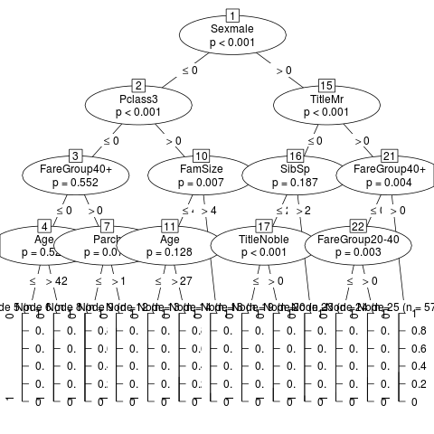

```python
%%R
plot(ctr.tune1$finalModel)
```

We can observe here that Sexmale as expected was the starting node. From then on, Pclass and TitleMr took the honors for level 2 leading further then to the other variables. We're now ready to evaluate the model and run the predictions.

**Model Evaluation - Conditional Trees**

```python
%%R
#Derive predictions using our final LR model on the test set (this is NOT the test.csv file from Kaggle)
ctr.pred<-predict(ctr.tune1, test.set)

#Generate the confusion matrix
confusionMatrix(ctr.pred, test.set$Survived)
```

```
Confusion Matrix and Statistics

          Reference
Prediction   0   1
         0 102  19
         1   7  49

               Accuracy : 0.8531
                 95% CI : (0.7922, 0.9017)
    No Information Rate : 0.6158
    P-Value [Acc > NIR] : 3.506e-12

                  Kappa : 0.6789
 Mcnemar's Test P-Value : 0.03098

            Sensitivity : 0.9358
            Specificity : 0.7206
         Pos Pred Value : 0.8430
         Neg Pred Value : 0.8750
             Prevalence : 0.6158
         Detection Rate : 0.5763
   Detection Prevalence : 0.6836
      Balanced Accuracy : 0.8282

       'Positive' Class : 0
```

So that gave us a better Specificity on the Test set at 72.06%. I am interested to see how this tests out at Kaggle.

**Submit to Kaggle**

```python
%%R
#Generate predictions and write as a dataframe, then include PassengerID
Survived<-predict(ctr.tune1, kaggletest)
ctr.predictions<-as.data.frame(Survived)
ctr.predictions$PassengerId<-kaggletest$PassengerId

#Write results as a CSV file
write.csv(ctr.predictions[,c('PassengerId','Survived')], file="CTR_Titanic_Predictions.csv", row.names=FALSE, quote=FALSE)
```

The model scored **0.77512** which is actually slightly worse than how Random Forests did. So the best model in terms of the Kaggle leaderboard has been Random Forests. But let's run a formal comparison of all the models we've built so far.

**Model Comparison**  
The resamples method in the caret package makes it easy to compare results between different models.

```python
%%R
modelcompare<-resamples(list(Logit = logit.tune6, SVM = svm.tune1, RF = rf.tune2, CTREE = ctr.tune1 ))
summary(modelcompare)
```

[output not shown]

**Box Plot of Model Comparison Results**

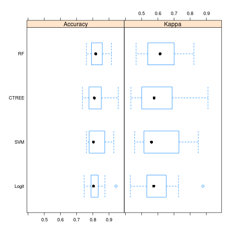

```python
%%R
bwplot(modelcompare)
```

**Dot Plot of Model Comparison Results**

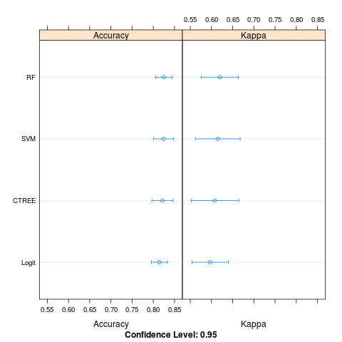

```python
%%R
dotplot(modelcompare)
```

So there you have it. We took the Titanic dataset presented by Kaggle, imported and visualized the data in a series of plots, munged the data to address gaps and fitted 4 different models with varying results, all in R, special thanks to the caret package. We only managed to get up to 0.7894 on the Kaggle leaderboard but the point of this exercise was to learn and demonstrate machine learning concepts in R. Hope we've achieved that objective.

I will be happy to receive your feedback positive or negative but try to be nice, I am just learning :-)